# EDAV Fall 2019 PSet 5, part A

This assignment is designed to help you get started on the final project. Be sure to review the final project instructions (https://edav.info/project.html), in particular the new section on reproducible workflow (https://edav.info/project.html#reproducible-workflow), which summarizes principles that we’ve discussed in class.

### 1. The Team

[2 points]

1. Who’s on the team? (Include names and UNIs)
- Amogh Mishra am5323
- Mohit Gulla mcg2208
- Benjamin Livingston bwl2114
- Siddhant Shandilya ss5919
2. How do you plan to divide up the work? (Grading is on a group basis. The point of asking is to encourage you to think about this.)

This will be determined over time. Mohit and Amogh focused on database querying early on during project choosing, and Siddhant and Benjamin are writing this specific report.

### 2. The Questions

[6 points]

List three questions that you hope you will be able to answer from your research.

1. Which airline is the best choice to use the Thanksgiving travel period?
2. Does this vary by region and time? Is there any variation between different days and times of day during the Thanksgiving holiday? Or does the winner stay constant
3. How does airline performance during this holiday compare to the baseline of how airlines usually handle delays?

### 3. Which output format do you plan to use to submit the project?

[2 points]

We will use an html_document, which will be sufficient for our needs.

### 4. The Data

What is your data source? What is your method for importing data? Please be specific. Provide relevant information such as any obstacles you’re encountering and what you plan to do to overcome them.

[5 points]

### 5. Provide a short summary, including 2-3 graphs, of your initial investigations.

[10 points]

```r
library(ggplot2)
library(dplyr)
library(ggthemes)

thanksgiving = read.csv('thanksgiving.csv')
alldates = read.csv('alldates.csv')
```

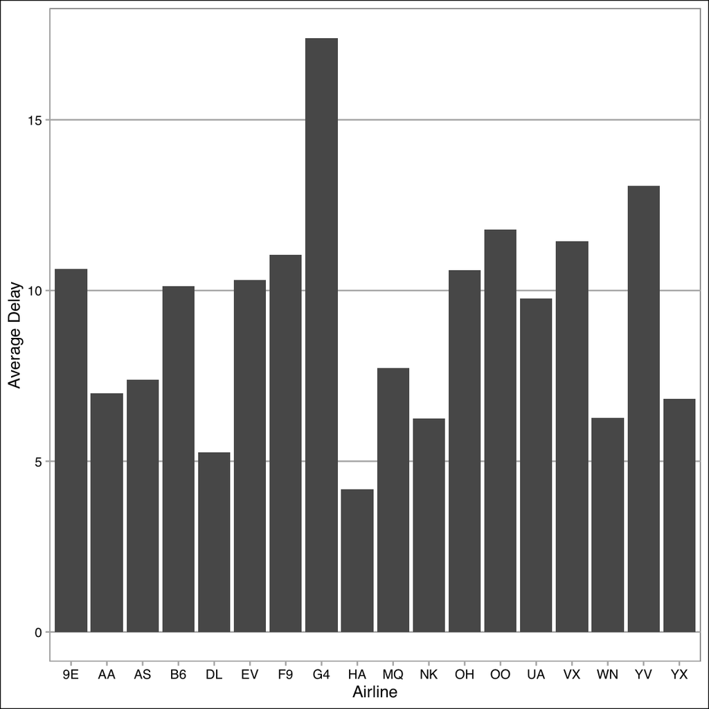

```r
by_airline = thanksgiving %>% group_by(OP_UNIQUE_CARRIER) %>% summarize(delay = mean(ARR_DELAY_NEW,na.rm=TRUE))

ggplot(by_airline,aes(x=OP_UNIQUE_CARRIER,y=delay)) +
  geom_col(position='dodge') +
  theme_calc() +
  xlab('Airline') +
  ylab('Average Delay')
```

Ultra low-cost carrier Allegiant (G4) leads the pack, which isn’t surprising considering its reputation (but wait, more on this in a second!). Regional airline Mesa Airlines comes next. Hawaiian Airlines has the fewest delays of any airline.

It is clear that focusing on large carriers will make the most sense for our purposes, since consumers are typically unfamiliar with regional airlines that fly under either a single mainline carrier’s brand or multiple brands, and those airlines tend to be available for only a small set of routes.

Among the three major legacy carriers, Delta (DL) has the fewest delays, followed by American Airlines (AA), and United (UA) performs by far the worst. Southwest (WN) performs a little better than American Airlines, and Alaska Airlines (AS) performs a little worse than American Airlines.

Does this change by year, though? How much does our data vary by year?

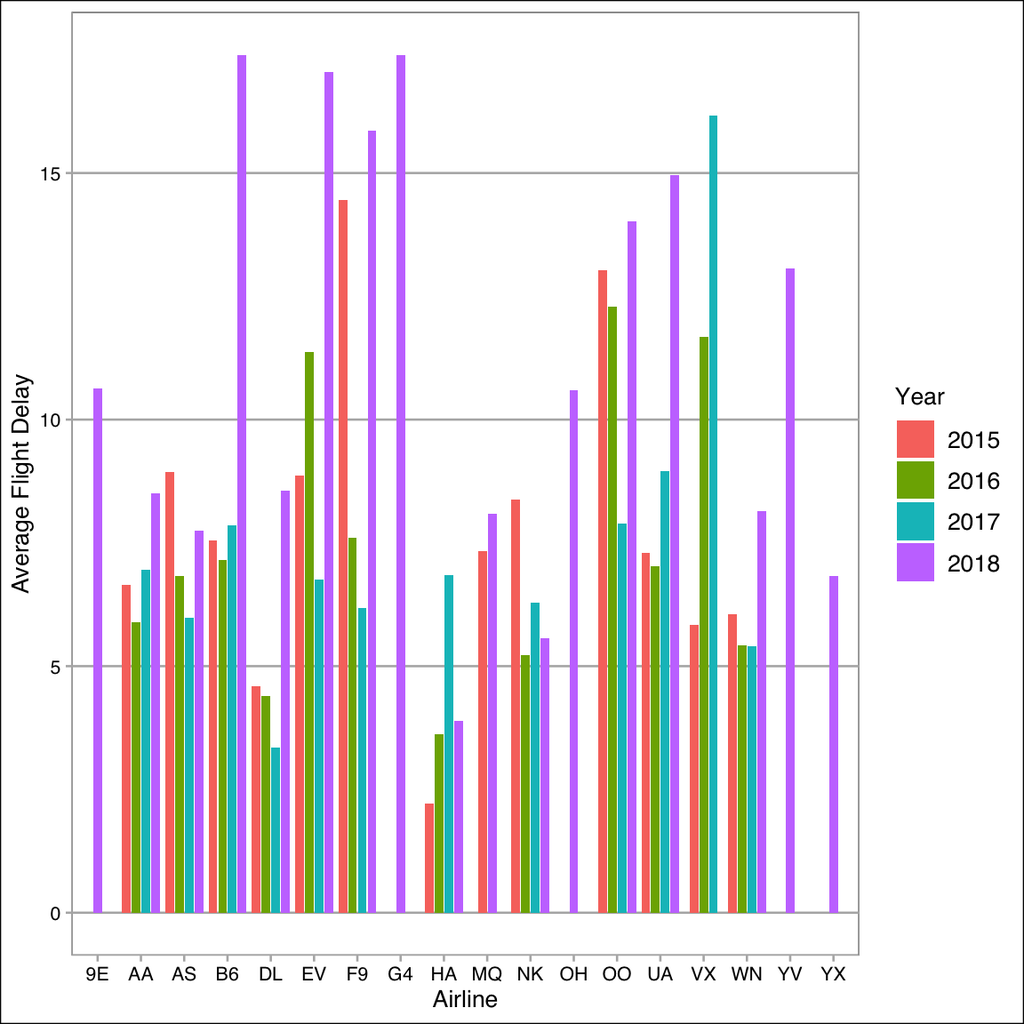

```r
by_year = thanksgiving %>% group_by(OP_UNIQUE_CARRIER,year) %>% summarize(delay = mean(ARR_DELAY_NEW,na.rm=TRUE))

ggplot(by_year,aes(x=OP_UNIQUE_CARRIER,y=delay,fill=as.factor(year))) +
  geom_col(position=position_dodge2(preserve = "single",width=1)) +
  scale_color_brewer(palette='Set3') +
  theme_calc() +
  xlab('Airline') +
  ylab('Average Flight Delay') +
  labs(fill = 'Year')
```

This also provides a curious revelation: Allegiant did not have any flights during the Thanksgiving holiday before 2018. No wonder its on time performance was so terrible - it only flew on Thanksgiving during the year when delays were by far the worst.

Again, this furthers our conviction that focusing on large, national, major mainline airlines that flew in all four years will make the most sense for our purposes.

We will apply the following criteria for removing airlines:

*Must have flown flights during Thanksgiving all four years* Regional or heavily region-specific airlines (regional airlines would be contracted carriers such as Mesa, heavily region-focused airlines would be like Hawaiian Airlines). *Inactive airlines

For this reason, we have decided to remove the following airlines: Remove: *Endeavor Air (9E)* ExpressJet (EV) *Allegiant (G4)* Hawaiian Airlines (HA) *Envoy Air (MQ)* PSA Airlines (OH) *SkyWest Airlines (OO)* Virgin America (VX) *Mesa Airlines (YV)* Republic Airways (YX)

Keep *American Airlines (AA)* Alaska Airlines (AS) *JetBlue (B6)* Delta (DL) *Frontier (F9)* Spirit (NK) *United Airlines (UA)* Southwest (WN)

```r
thanksgiving = thanksgiving %>% mutate(OP_UNIQUE_CARRIER = recode(OP_UNIQUE_CARRIER, "9E" = "Endeavor Air",
                                                                  "EV" = "ExpressJet",
                                                                  "G4" = "Allegiant",
                                                                  "HA" = "Hawaiian",
                                                                  "MQ" = "Envoy",
                                                                  "OH" = "PSA",
                                                                  "OO" = "SkyWest",
                                                                  "VX" = "Virgin America",
                                                                  "YV" = "Mesa",
                                                                  "YX" = "Republic",
                                                                  "AA" = "American",
                                                                  "AS" = "Alaska",
                                                                  "B6" = "JetBlue",
                                                                  "DL" = "Delta",
                                                                  "F9" = "Frontier",
                                                                  "NK" = "Spirit",
                                                                  "UA" = "United",
                                                                  "WN" = "Southwest"))
```

```r
thanksgiving = thanksgiving %>% filter(OP_UNIQUE_CARRIER %in% c('American','Alaska','JetBlue','Delta','Frontier','Spirit','United','Southwest'))
```

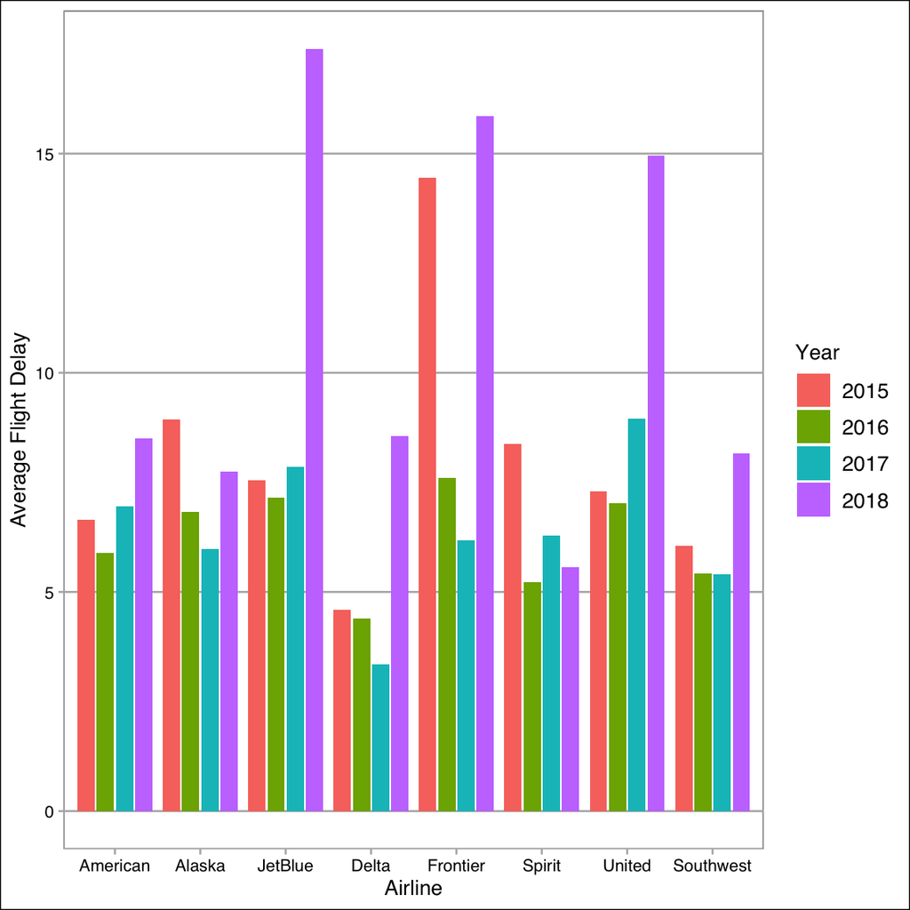

```r
by_year = thanksgiving %>% group_by(OP_UNIQUE_CARRIER,year) %>% summarize(delay = mean(ARR_DELAY_NEW,na.rm=TRUE))

ggplot(by_year,aes(x=OP_UNIQUE_CARRIER,y=delay,fill=as.factor(year))) +
  geom_col(position=position_dodge2(preserve = "single",width=1)) +
  scale_color_brewer(palette='Set3') +
  theme_calc() +
  xlab('Airline') +
  ylab('Average Flight Delay') +
  labs(fill = 'Year')
```

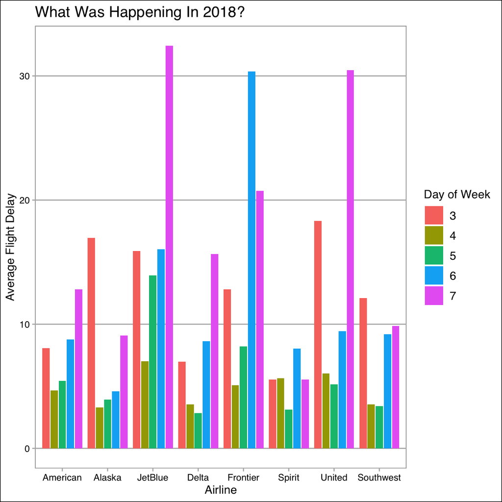

```r
by_day = thanksgiving %>% filter(year==2018) %>% group_by(OP_UNIQUE_CARRIER,DAY_OF_WEEK) %>% summarize(delay = mean(ARR_DELAY_NEW,na.rm=TRUE))

ggplot(by_day,aes(x=OP_UNIQUE_CARRIER,y=delay,fill=as.factor(DAY_OF_WEEK))) +
  geom_col(position=position_dodge2(preserve = "single",width=1)) +
  scale_color_brewer(palette='Set3') +
  theme_calc() +
  xlab('Airline') +
  ylab('Average Flight Delay') +
  labs(fill = 'Day of Week') +
  ggtitle('What Was Happening In 2018?')
```

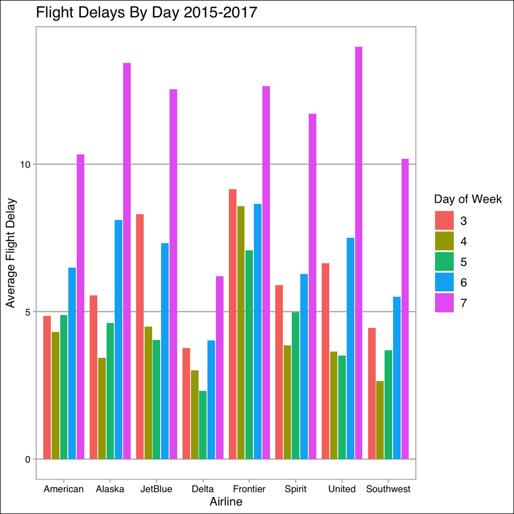

```r
by_day = thanksgiving %>% filter(year!=2018) %>% group_by(OP_UNIQUE_CARRIER,DAY_OF_WEEK) %>% summarize(delay = mean(ARR_DELAY_NEW,na.rm=TRUE))

ggplot(by_day,aes(x=OP_UNIQUE_CARRIER,y=delay,fill=as.factor(DAY_OF_WEEK))) +
  geom_col(position=position_dodge2(preserve = "single",width=1)) +
  scale_color_brewer(palette='Set3') +
  theme_calc() +
  xlab('Airline') +
  ylab('Average Flight Delay') +
  labs(fill = 'Day of Week') +
  ggtitle('Flight Delays By Day 2015-2017')
```

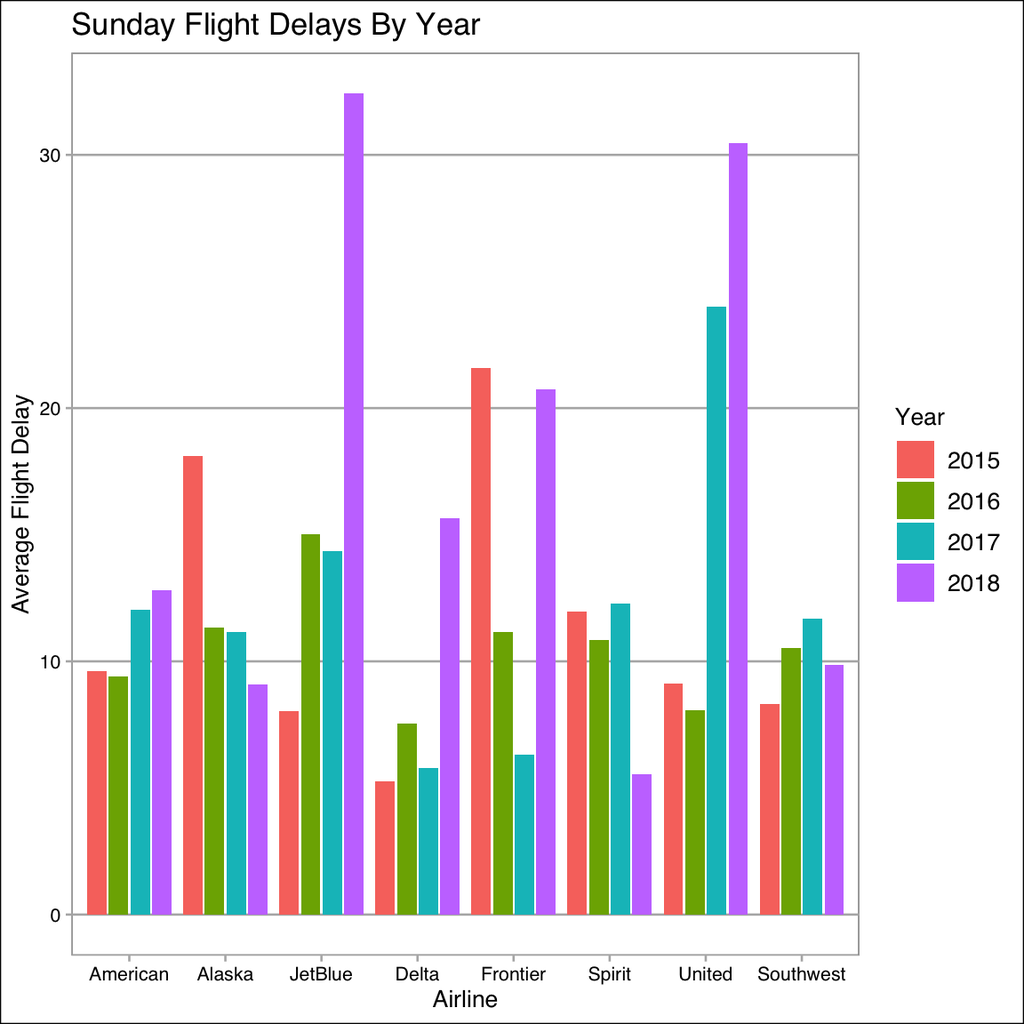

```r
by_year_sunday = thanksgiving %>% filter(DAY_OF_WEEK==7) %>% group_by(OP_UNIQUE_CARRIER,year) %>% summarize(delay = mean(ARR_DELAY_NEW,na.rm=TRUE))

ggplot(by_year_sunday,aes(x=OP_UNIQUE_CARRIER,y=delay,fill=as.factor(year))) +
  geom_col(position=position_dodge2(preserve = "single",width=1)) +
  scale_color_brewer(palette='Set3') +
  theme_calc() +
  xlab('Airline') +
  ylab('Average Flight Delay') +
  labs(fill = 'Year') +
  ggtitle('Sunday Flight Delays By Year')
```

```r
sunday2018 = thanksgiving %>% filter(year == 2018,DAY_OF_WEEK==7) %>% group_by(ORIGIN) %>% summarize(cancellations = sum(CANCELLED,na.rm=TRUE)) %>% arrange(-cancellations)

head(sunday2018,30)
```

```
## # A tibble: 30 x 2
##    ORIGIN cancellations
##    <fct>          <int>
##  1 ORD              123
##  2 MCI               66
##  3 MDW               53
##  4 LGA               19
##  5 DEN               18
##  6 DFW               16
##  7 LAX               13
##  8 ATL               12
##  9 BOS               11
## 10 LAS               11
## # … with 20 more rows
```

Now let’s do a brief look into regionality, looking at the 15 states/territories with the worst delays.

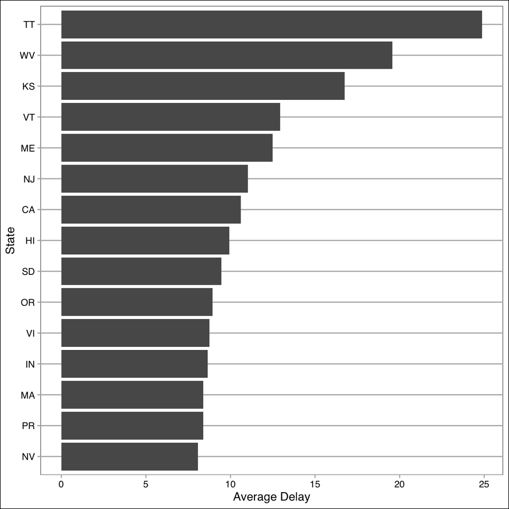

```r
library(forcats)
by_area = thanksgiving %>% group_by(ORIGIN_STATE_ABR) %>% summarize(average_delay = mean(DEP_DELAY_NEW,na.rm=TRUE),number_of_flights=n()) %>% arrange(-average_delay) %>% head(15)

ggplot(by_area) +
  geom_col(aes(x=fct_reorder(ORIGIN_STATE_ABR,average_delay),y=average_delay)) +
  theme_calc() +
  coord_flip() +
  xlab('State') +
  ylab('Average Delay')
```

The Pacific Islands lead the pack, but there are barely any flights there. Many small states have the worst OTP, which may be due to high variance.

Let’s try only taking states with more than 1000 flights.

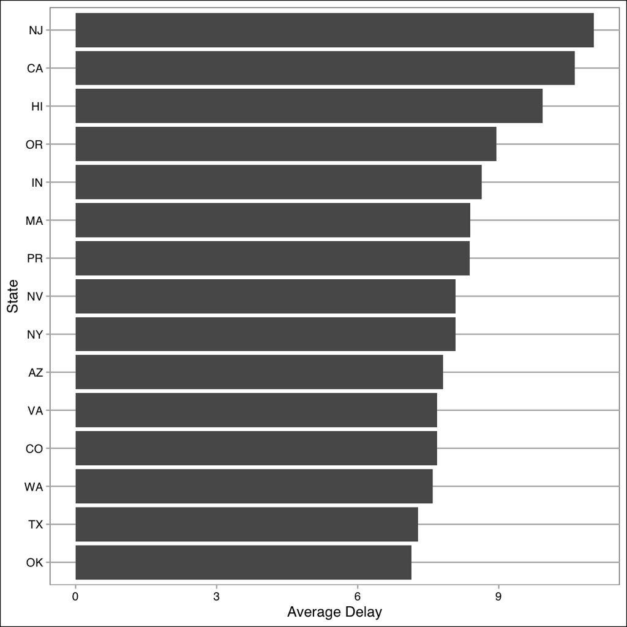

```r
by_area = thanksgiving %>% group_by(ORIGIN_STATE_ABR) %>% summarize(average_delay = mean(DEP_DELAY_NEW,na.rm=TRUE),number_of_flights=n()) %>% arrange(-average_delay) %>% filter(number_of_flights >1000) %>% head(15)

ggplot(by_area) +
  geom_col(aes(x=fct_reorder(ORIGIN_STATE_ABR,average_delay),y=average_delay)) +
  theme_calc() +
  coord_flip() +
  xlab('State') +
  ylab('Average Delay')
```

We will leave it there for now, as we certainly have some questions to consider as we begin our project.

```r
thanksgiving_region<- thanksgiving %>% mutate(region = if_else(DEST_STATE_ABR=="AK","West",
                                                       if_else(DEST_STATE_ABR=="AL","South",
                                                       if_else(DEST_STATE_ABR=="AR","South",
                                                       if_else(DEST_STATE_ABR=="AZ","West",
                                                       if_else(DEST_STATE_ABR=="CA","West",
                                                       if_else(DEST_STATE_ABR=="CO","West",
                                                       if_else(DEST_STATE_ABR=="CT","Northeast",
                                                       if_else(DEST_STATE_ABR=="DC","South",
                                                       if_else(DEST_STATE_ABR=="DE","South",
                                                       if_else(DEST_STATE_ABR=="FL","South",
                                                       if_else(DEST_STATE_ABR=="GA","South",
                                                       if_else(DEST_STATE_ABR=="HI","West",
                                                       if_else(DEST_STATE_ABR=="IA","Midwest",
                                                       if_else(DEST_STATE_ABR=="ID","West",
                                                       if_else(DEST_STATE_ABR=="IL","Midwest",
                                                       if_else(DEST_STATE_ABR=="IN","Midwest",
                                                       if_else(DEST_STATE_ABR=="KS","Midwest",
                                                       if_else(DEST_STATE_ABR=="KY","South",
                                                       if_else(DEST_STATE_ABR=="LA","South",
                                                       if_else(DEST_STATE_ABR=="MA","Northeast",
                                                       if_else(DEST_STATE_ABR=="MD","South",
                                                       if_else(DEST_STATE_ABR=="ME","Northeast",
                                                       if_else(DEST_STATE_ABR=="MI","Midwest",
                                                       if_else(DEST_STATE_ABR=="MN","Midwest",
                                                       if_else(DEST_STATE_ABR=="MO","Midwest",
                                                       if_else(DEST_STATE_ABR=="MS","South",
                                                       if_else(DEST_STATE_ABR=="MT","West",
                                                       if_else(DEST_STATE_ABR=="NC","South",
                                                       if_else(DEST_STATE_ABR=="ND","Midwest",
                                                       if_else(DEST_STATE_ABR=="NE","Midwest",
                                                       if_else(DEST_STATE_ABR=="NH","Northeast",
                                                       if_else(DEST_STATE_ABR=="NJ","Northeast",
                                                       if_else(DEST_STATE_ABR=="NM","West",
                                                       if_else(DEST_STATE_ABR=="NV","West",
                                                       if_else(DEST_STATE_ABR=="NY","Northeast",
                                                       if_else(DEST_STATE_ABR=="OH","Midwest",
                                                       if_else(DEST_STATE_ABR=="OK","South",
                                                       if_else(DEST_STATE_ABR=="OR","West",
                                                       if_else(DEST_STATE_ABR=="PA","Northeast",
                                                       if_else(DEST_STATE_ABR=="RI","Northeast",
                                                       if_else(DEST_STATE_ABR=="SC","South",
                                                       if_else(DEST_STATE_ABR=="SD","Midwest",
                                                       if_else(DEST_STATE_ABR=="TN","South",
                                                       if_else(DEST_STATE_ABR=="TX","South",
                                                       if_else(DEST_STATE_ABR=="UT","West",
                                                       if_else(DEST_STATE_ABR=="VA","South",
                                                       if_else(DEST_STATE_ABR=="VT","Northeast",
                                                       if_else(DEST_STATE_ABR=="WA","West",""
                                                          )))))))))))))))))))))))))))))))))))))))))))))))))

thanksgiving_region$region<- ifelse(thanksgiving_region$DEST_STATE_ABR=="WI" & thanksgiving_region$region =="","Midwest",
                                                      ifelse(thanksgiving_region$DEST_STATE_ABR=="WV" & thanksgiving_region$region =="","South",
                                                       ifelse(thanksgiving_region$DEST_STATE_ABR=="AL" & thanksgiving_region$region =="","South",
                                                       ifelse(thanksgiving_region$DEST_STATE_ABR=="WY" & thanksgiving_region$region=="","West",thanksgiving_region$region))))

thanksgiving_region<-thanksgiving_region %>% filter(!region %in% c(""))
```

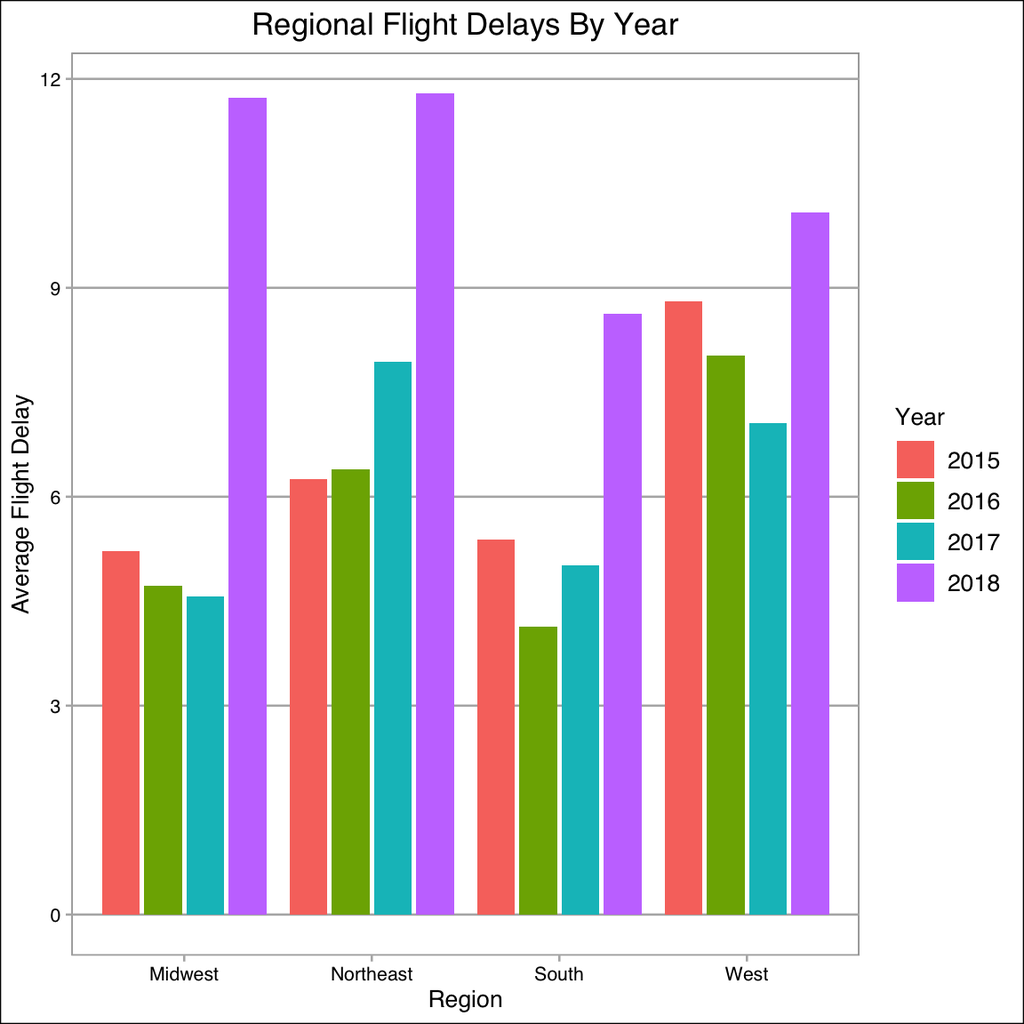

```r
by_region_delay = thanksgiving_region %>% group_by(region,year) %>% summarize(delay = mean(ARR_DELAY_NEW,na.rm=TRUE))

ggplot(by_region_delay,aes(x=region,y=delay,fill=as.factor(year))) +
  geom_col(position=position_dodge2(preserve = "single",width=1)) +
  scale_color_brewer(palette='Set4') +
  theme_calc() +
  xlab('Region') +
  ylab('Average Flight Delay') +
  labs(fill = 'Year') +
  ggtitle('Regional Flight Delays By Year')+
  theme(plot.title = element_text(hjust = 0.5))
```

From the above plot, we see that there is certainly something wrong with 2018 since the average delay is consistently high for all the four years. Moreover, looking at the above graph it’s difficult to decipher which region has the best performance in terms of OTP. Let’s have a look at the mosaic plot between region and a variable indicating whether there was a delay or not.

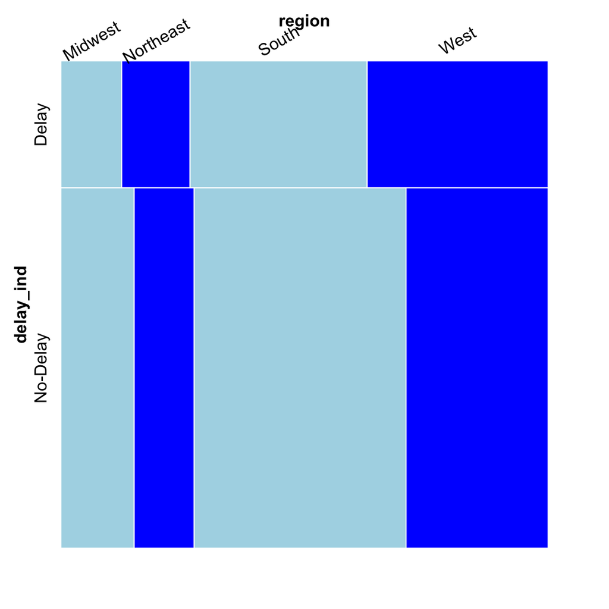

```r
by_region_delay = thanksgiving_region %>% mutate(delay_ind = if_else(thanksgiving_region$ARR_DELAY_NEW >0,"Delay","No-Delay")) %>% group_by(region,delay_ind) %>% summarise(Freq=n())

vcd::mosaic(region ~ delay_ind,
       gp = grid::gpar(fill = c("lightblue", "blue"),
                 col = "white"),
       spacing = vcd::spacing_equal(sp = unit(0, "lines")),
       by_region_delay,
       labeling=vcd::labeling_border(rot_labels = c(30,0,0,90)))
```

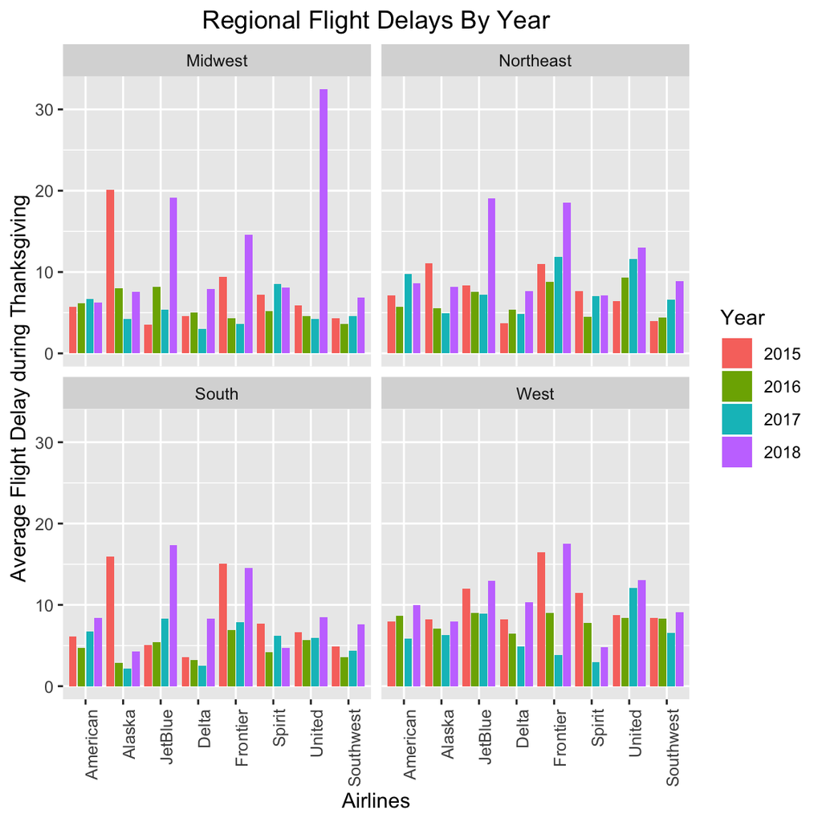

```r
by_flight_delay = thanksgiving_region %>% group_by(OP_UNIQUE_CARRIER,year,region) %>% summarize(delay = mean(ARR_DELAY_NEW,na.rm=TRUE))

ggplot(by_flight_delay,aes(x=OP_UNIQUE_CARRIER,y=delay,fill=as.factor(year))) +
  geom_col(position=position_dodge2(preserve = "single",width=1)) +
  theme(axis.text.x = element_text(angle = 90, hjust = 1))+
  scale_color_brewer(palette='Set4') +
  xlab('Airlines') +
  facet_wrap(~region)+
  ylab('Average Flight Delay during Thanksgiving') +
  labs(fill = 'Year') +
  ggtitle('Regional Flight Delays By Year')+
  theme(plot.title = element_text(hjust = 0.5))
```

With a cusory glance, it seems that the OTP for all the regions are same there. But delving deeper into it surely gives some inference and it tells that there is definitely some difference in the OTP between the airlines and the region they fly in.

Here, we see that in the South, Delta and Southwest airlines have the best performance followed by American airlines which is quite intuitive and a little research tells us that Southwest has its base in Dallas, TX allowing it to have a leverage over the other airlines. American airlines is also headquartered in Fort Worth, TX making it the second best OTP airline (At least based on the data). Even though most airlines were affected in 2018, the aforementioned airlines played it well. Overall the southern region seem to performing really well than the other 3. However the difference is not statistically significant and hence in order to draw some inference, we need to move towards more granular approach.

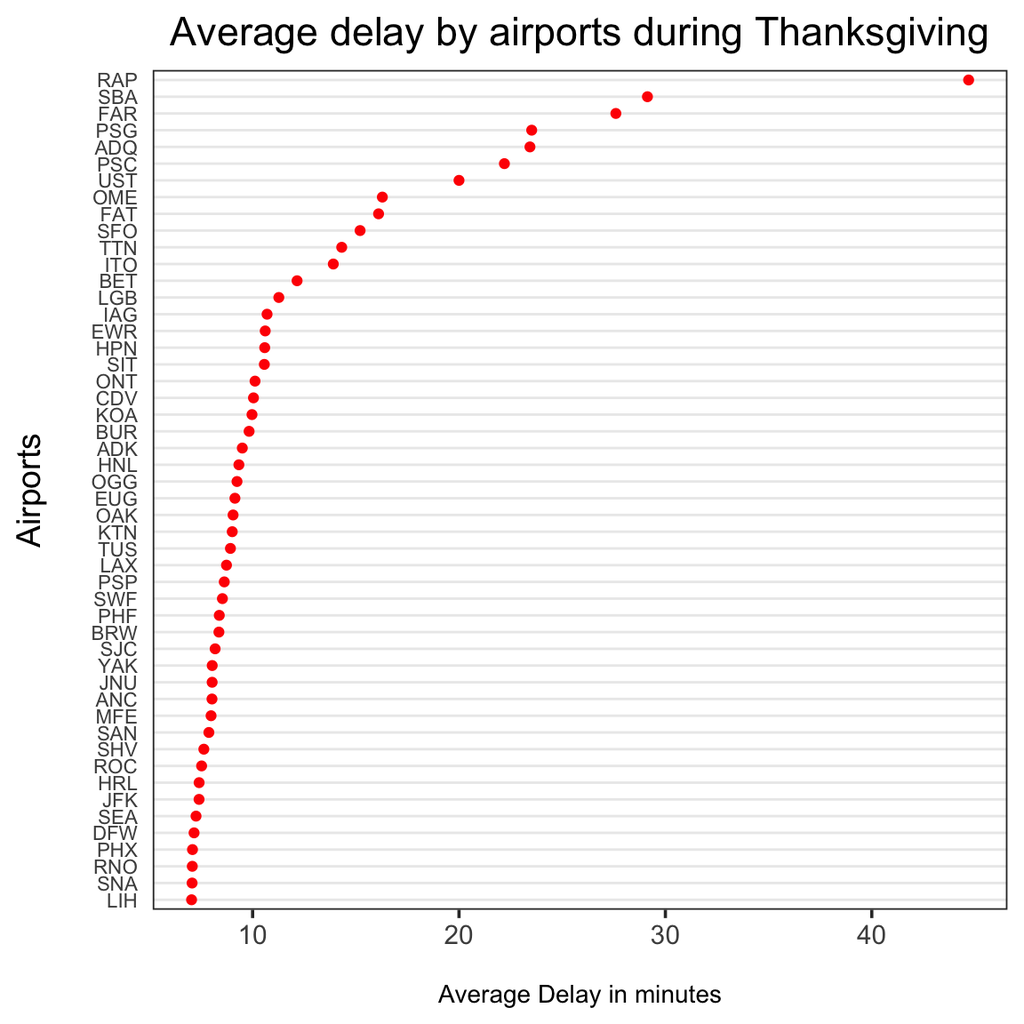

```r
thanksgiving_region_dot_plot<-thanksgiving_region[thanksgiving_region$year!=2018,] %>% group_by(DEST) %>%
                              summarise(delay=mean(ARR_DELAY_NEW,na.rm=TRUE)) %>% arrange(-delay)

thanksgiving_region_dot_plot<-thanksgiving_region_dot_plot[c(1:50),]

thanksgiving_region_dot_plot<-unique(merge(thanksgiving_region_dot_plot,thanksgiving_region[,c("DEST","region")],by="DEST",all.x = TRUE))


theme_dotplot <- theme_bw(14) +
    theme(axis.text.y = element_text(size = rel(.75)),
        axis.ticks.y = element_blank(),
        axis.title.x = element_text(size = rel(.75)),
        panel.grid.major.x = element_blank(),
        panel.grid.major.y = element_line(size = 0.5),
        panel.grid.minor.x = element_blank())

# create the plot
ggplot(thanksgiving_region_dot_plot, aes(x = delay, y = reorder(DEST, delay),color=region)) +
    geom_point(color = "red") +
    theme_dotplot +
    xlab("\nAverage Delay in minutes") +
    ylab("Airports\n") +
    ggtitle("Average delay by airports during Thanksgiving")+
  theme(plot.title = element_text(hjust = 0.5))
```

A cleveland dot plot of average delay time with respect to the airports tells us that the worst affected airports are the Rapid city regional airport in south Dakota, Santa Barbara Airport based out of California, Hector International airport based out of North Dakota. Since these are small and not so famous airports where people genrally rush to during thanksgiving holidays, we try to go beyond this cleveland dot plot and consider top busiest airports in the US.

Comparing by airports now (Region is too specific)

```r
alldates = alldates %>% mutate(OP_UNIQUE_CARRIER = recode(OP_UNIQUE_CARRIER, "9E" = "Endeavor Air",
                                                                  "EV" = "ExpressJet",
                                                                  "G4" = "Allegiant",
                                                                  "HA" = "Hawaiian",
                                                                  "MQ" = "Envoy",
                                                                  "OH" = "PSA",
                                                                  "OO" = "SkyWest",
                                                                  "VX" = "Virgin America",
                                                                  "YV" = "Mesa",
                                                                  "YX" = "Republic",
                                                                  "AA" = "American",
                                                                  "AS" = "Alaska",
                                                                  "B6" = "JetBlue",
                                                                  "DL" = "Delta",
                                                                  "F9" = "Frontier",
                                                                  "NK" = "Spirit",
                                                                  "UA" = "United",
                                                                  "WN" = "Southwest"))
 alldates = alldates %>% filter(OP_UNIQUE_CARRIER %in% c('American','Alaska','JetBlue','Delta','Frontier','Spirit','United','Southwest'))
```

```r
top_10_airports<-alldates %>% group_by(DEST) %>% summarise(cnt =n()) %>% arrange(-cnt)
top_10_airports<-top_10_airports$DEST[1:10]
alldates_top10<-alldates[alldates$DEST %in% top_10_airports,]
```

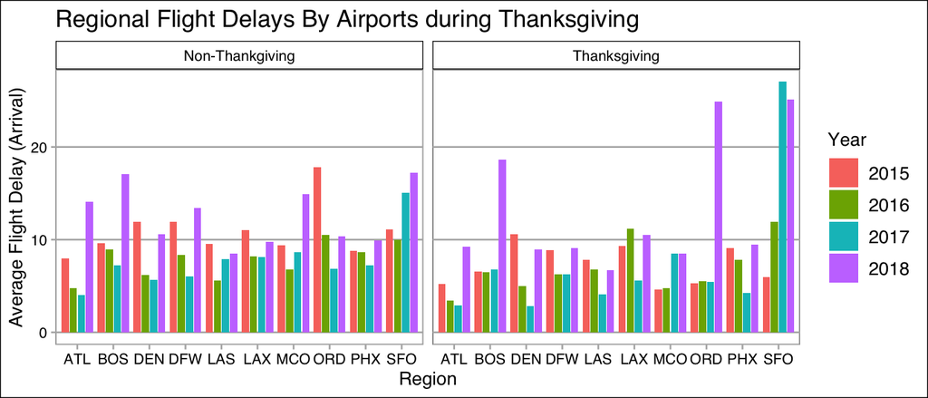

```r
by_airport_delay_tg = alldates_top10[alldates_top10$period =="Thanksgiving",] %>% group_by(DEST,year,period) %>% summarize(delay = mean(ARR_DELAY_NEW,na.rm=TRUE))

by_airport_delay_ntg = alldates_top10[alldates_top10$period =="Non-Thankgiving",] %>% group_by(DEST,year,period) %>% summarize(delay = mean(ARR_DELAY_NEW,na.rm=TRUE))

by_airport_delay<-bind_rows(by_airport_delay_tg,by_airport_delay_ntg)

ggplot(by_airport_delay,aes(x=DEST,y=delay,fill=as.factor(year))) +
  geom_col(position=position_dodge2(preserve = "single",width=1)) +
  facet_wrap(~period)+
  scale_color_brewer(palette='Set4') +
  theme_calc() +
  xlab('Region') +
  ylab('Average Flight Delay (Arrival)') +
  labs(fill = 'Year') +
  ggtitle('Regional Flight Delays By Airports during Thanksgiving')
```

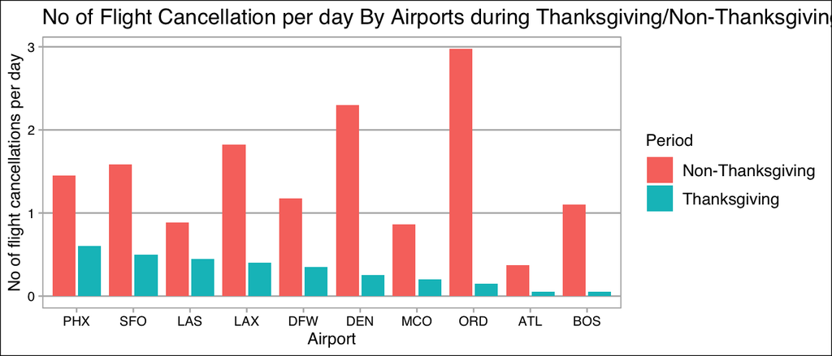

```r
library(ggpubr)
alldates_top10_cancellations_Thanksgiving <- alldates_top10[alldates_top10$period =="Thanksgiving" &alldates_top10$year!=2018,] %>% group_by(DEST) %>% summarise(No_of_cnc = sum(CANCELLED,na.rm=TRUE)/20) %>% arrange(-No_of_cnc)

alldates_top10_cancellations_Thanksgiving<-alldates_top10_cancellations_Thanksgiving[c(1:10),]

alldates_top10_cancellations_Thanksgiving$DEST <-
  factor(alldates_top10_cancellations_Thanksgiving$DEST,
         levels = alldates_top10_cancellations_Thanksgiving$DEST
         [order(-alldates_top10_cancellations_Thanksgiving$No_of_cnc)])



  alldates_top10_cancellations_Non_Thanksgiving <- alldates_top10[alldates_top10$period =="Non-Thankgiving" &alldates_top10$year!=2018,] %>% group_by(DEST) %>% summarise(No_of_cnc = sum(CANCELLED,na.rm=TRUE)/80) %>% arrange(-No_of_cnc)

  alldates_top10_cancellations_Non_Thanksgiving<-alldates_top10_cancellations_Non_Thanksgiving[c(1:10),]

  alldates_top10_cancellations_Non_Thanksgiving$DEST <-
    factor(alldates_top10_cancellations_Non_Thanksgiving$DEST,
           levels = alldates_top10_cancellations_Non_Thanksgiving$DEST
           [order(-alldates_top10_cancellations_Non_Thanksgiving$No_of_cnc)])

  alldates_top10_cancellations_Thanksgiving$period<-"Thanksgiving"
alldates_top10_cancellations_Non_Thanksgiving$period<-"Non-Thanksgiving"
no_of_cancellations<-bind_rows(alldates_top10_cancellations_Thanksgiving,alldates_top10_cancellations_Non_Thanksgiving)

ggplot(no_of_cancellations,aes(x=DEST,y=No_of_cnc,fill=as.factor(period))) +
  geom_col(position=position_dodge2(preserve = "single",width=1)) +
  scale_color_brewer(palette='Set3') +
  theme_calc() +
  xlab('Airport') +
  ylab('No of flight cancellations per day') +
  labs(fill = 'Period') +
  ggtitle('No of Flight Cancellation per day By Airports during Thanksgiving/Non-Thanksgiving')
```

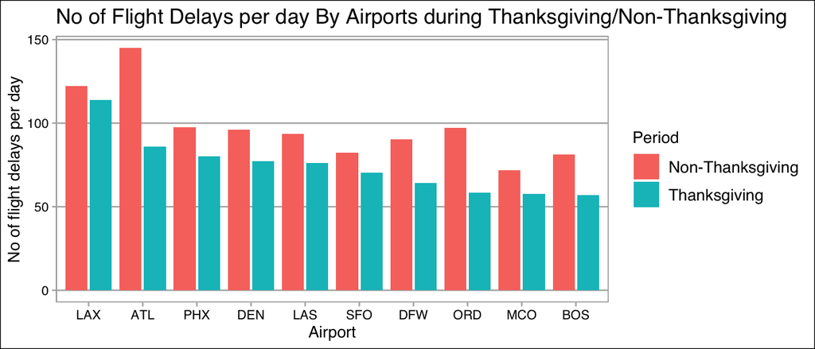

```r
library(reshape2)
alldates_top10_delays_Thanksgiving <- alldates_top10[alldates_top10$period =="Thanksgiving" &alldates_top10$year!=2018,] %>% group_by(DEST) %>% summarise(No_of_delay = sum(if_else(ARR_DELAY_NEW>0,1,0),na.rm=TRUE)/20) %>% arrange(-No_of_delay)

alldates_top10_delays_Thanksgiving<-alldates_top10_delays_Thanksgiving[c(1:10),]

alldates_top10_delays_Thanksgiving$DEST <-
  factor(alldates_top10_delays_Thanksgiving$DEST,
         levels = alldates_top10_delays_Thanksgiving$DEST
         [order(-alldates_top10_delays_Thanksgiving$No_of_delay)])

alldates_top10_delays_Non_Thanksgiving <- alldates_top10[alldates_top10$period =="Non-Thankgiving" &alldates_top10$year!=2018,] %>% group_by(DEST) %>% summarise(No_of_delay = sum(if_else(ARR_DELAY_NEW>0,1,0),na.rm=TRUE)/80) %>% arrange(-No_of_delay)

alldates_top10_delays_Non_Thanksgiving<-alldates_top10_delays_Non_Thanksgiving[c(1:10),]

alldates_top10_delays_Non_Thanksgiving$DEST <-
  factor(alldates_top10_delays_Non_Thanksgiving$DEST,
         levels = alldates_top10_delays_Non_Thanksgiving$DEST
         [order(-alldates_top10_delays_Non_Thanksgiving$No_of_delay)])

alldates_top10_delays_Thanksgiving$period<-"Thanksgiving"
alldates_top10_delays_Non_Thanksgiving$period<-"Non-Thanksgiving"
no_of_delays<-bind_rows(alldates_top10_delays_Thanksgiving,alldates_top10_delays_Non_Thanksgiving)

ggplot(no_of_delays,aes(x=DEST,y=No_of_delay,fill=as.factor(period))) +
  geom_col(position=position_dodge2(preserve = "single",width=1)) +
  scale_color_brewer(palette='Set3') +
  theme_calc() +
  xlab('Airport') +
  ylab('No of flight delays per day') +
  labs(fill = 'Period') +
  ggtitle('No of Flight Delays per day By Airports during Thanksgiving/Non-Thanksgiving')
```